# Multiple Regression_Layoff

pg611@scarletmail.rutgers.edu

2024-04-15

```r
lay_data <- read.csv("/Users/parul/OneDrive/Desktop/MVA/Layoff_Data.csv", row.names=1)

str(lay_data)
```

```
## 'data.frame':    50 obs. of  9 variables:
##  $ Laid_Off             : int  200 100 350 100 900 130 235 225 15 839 ...
##  $ Percentage           : int  15 20 10 12 24 29 16 11 33 100 ...
##  $ Before_Layoffs       : int  1333 500 3500 1000 3750 450 1567 2045 45 839 ...
##  $ After_layoffs        : int  1133 400 3150 900 2850 320 1332 1820 30 0 ...
##  $ Money_Raised_in_._mil: int  1700 733 116 1500 15000 1300 2500 97 302 194 ...
##  $ lat                  : num  13 32.8 37.5 13 37.8 ...
##  $ lng                  : num  77.6 35 -122 77.6 -122.4 ...
##  $ Laid_Off_Yes_No      : chr  "Yes" "No" "Yes" "No" ...
##  $ layoff               : int  1 0 1 0 1 0 1 1 0 1 ...
```

```r
colnames(lay_data) <- c("Laidoff", "Percentage", "BeforeLayoff", "AfterLayoff", "MoneyRaised", "lat", "lng", "laidOff", "layoff")
```

```r
# MODEL DEVELOPMENT


# Performing multiple regression on mtcars dataset
fit <- lm(layoff~Percentage + BeforeLayoff + AfterLayoff + MoneyRaised + lat + lng, data=lay_data) # LM- ASSUMES IT TO BE IT LINEAR, y(mpg)- many variables-output-residuals means error -median of the errors- median means real minus predicted

#show the results
```

INSIGHTS : The lm() function fits a linear regression model to the data, where the response variable (layoff) is modeled as a linear combination of the predictor variables (Percentage, BeforeLayoff, AfterLayoff, MoneyRaised, lat, lng).

```r
# MODEL ACCEPTANCE

summary(fit)
```

```
##
## Call:
## lm(formula = layoff ~ Percentage + BeforeLayoff + AfterLayoff +
##     MoneyRaised + lat + lng, data = lay_data)
##
## Residuals:
##     Min      1Q  Median      3Q     Max
## -0.7063 -0.2132 -0.1360  0.0612  0.7863
##
## Coefficients:
##                Estimate Std. Error t value Pr(>|t|)
## (Intercept)  -7.220e-02  2.537e-01  -0.285  0.77728
## Percentage    1.253e-03  2.812e-03   0.446  0.65812
## BeforeLayoff  9.551e-04  2.850e-04   3.351  0.00169 **
## AfterLayoff  -9.410e-04  2.996e-04  -3.140  0.00305 **
## MoneyRaised   1.396e-05  2.837e-05   0.492  0.62519
## lat           3.165e-03  6.627e-03   0.478  0.63532
## lng          -5.975e-05  8.544e-04  -0.070  0.94457
## ---
## Signif. codes:  0 '***' 0.001 '**' 0.01 '*' 0.05 '.' 0.1 ' ' 1
##
## Residual standard error: 0.3637 on 43 degrees of freedom
## Multiple R-squared:  0.5061, Adjusted R-squared:  0.4372
## F-statistic: 7.344 on 6 and 43 DF,  p-value: 1.91e-05
```

```r
#Summary has three sections. Section1: How well does the model fit the data (before Coefficients). Section2: Is the hypothesis supported? (until sifnif codes). Section3: How well does data fit the model (again).
```

INSIGHTS : The model’s adjusted R-squared value is 0.4372, indicating that approximately 43.72% of the variability in layoff can be explained by the predictor variables included in the model. The F-statistic tests the overall significance of the model and suggests that the model as a whole is statistically significant (p-value: 1.91e-05).

```r
#for values pr|>t|) greater than 0.05, its not considered right
fit <- lm(layoff~Percentage + BeforeLayoff + AfterLayoff + MoneyRaised + lat + lng, data=lay_data)#removed the values that were 0.05
# Useful Helper Functions
coefficients(fit)
```

```
##   (Intercept)    Percentage  BeforeLayoff   AfterLayoff   MoneyRaised
## -7.220222e-02  1.253125e-03  9.551032e-04 -9.410057e-04  1.395757e-05
##           lat           lng
##  3.165247e-03 -5.975064e-05
```

```r
library(GGally)
```

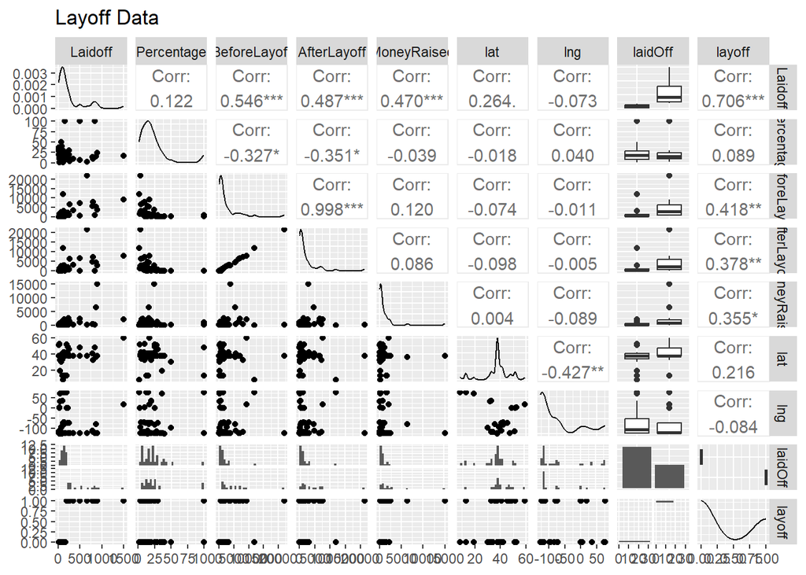

```r
ggpairs(data=lay_data, title="Layoff Data")
```

```r
confint(fit,level=0.95)#confidence interval
```

```
##                      2.5 %        97.5 %
## (Intercept)  -5.837368e-01  0.4393323158
## Percentage   -4.418237e-03  0.0069244860
## BeforeLayoff  3.803243e-04  0.0015298820
## AfterLayoff  -1.545306e-03 -0.0003367052
## MoneyRaised  -4.324846e-05  0.0000711636
## lat          -1.019893e-02  0.0165294216
## lng          -1.782912e-03  0.0016634105
```

```r
fitted(fit)
```

```
##             ShareChat             InSightec        Enphase Energy
##            0.21373870            0.16602826            0.44677968
##                 Udaan                Cruise                  Bolt
##            0.10839285            1.19388861            0.23783936
##               Invitae                  Etsy          Chipper Cash
##            0.35285021            0.31678435            0.11499725
##                Zulily             ZestMoney                 Navan
##            1.01514440            0.23353275            0.26790946
##          Incredibuild               Spotify                  Loco
##            0.09327425            1.70632960            0.06885653
##                  Zepz                 Unity              Dataminr
##            0.15249542            0.42059915            0.25323017
##       Our Next Energy        Physics Wallah           TripAdvisor
##            0.23118744            0.23479653            0.23285320
##                Viasat           Beyond Meat                Splunk
##            0.92157578            0.12700106            0.66815051
##                 Faire         Sana Benefits       Hippo Insurance
##            0.35634380            0.16432836            0.21819519
##                SiFive          Nomad Health                Convoy
##            0.21497076            0.20728417            0.70400998
##              Bullhorn           StellarAlgo              ManoMano
##            0.23152573            0.15232988            0.35285972
## WeTranSan Franciscoer              LinkedIn                  C2FO
##            0.14457619            0.99048799            0.18134220
##          Lending Club               MariaDB              Deepgram
##            0.25687328            0.17590912            0.10129160
##         Carbon Health           InvestCloud            SchoolMint
##            0.20770750            0.14750236            0.10272139
##               Arrival             Qualtrics                Hopper
##            0.33042905            0.89914950            0.37101879
##           Chainalysis               Synapse          Chia Network
##            0.24261685            0.18969870            0.12747500
##               Cowbell            Epic Games
##            0.10067790            1.05043947
```

```r
# Residual ANALYSIS


residuals(fit)
```

```
##             ShareChat             InSightec        Enphase Energy
##           0.786261301          -0.166028256           0.553220322
##                 Udaan                Cruise                  Bolt
##          -0.108392851          -0.193888611          -0.237839361
##               Invitae                  Etsy          Chipper Cash
##           0.647149791           0.683215650          -0.114997252
##                Zulily             ZestMoney                 Navan
##          -0.015144403          -0.233532749          -0.267909458
##          Incredibuild               Spotify                  Loco
##          -0.093274247          -0.706329596          -0.068856533
##                  Zepz                 Unity              Dataminr
##          -0.152495422           0.579400847          -0.253230174
##       Our Next Energy        Physics Wallah           TripAdvisor
##          -0.231187441          -0.234796534          -0.232853201
##                Viasat           Beyond Meat                Splunk
##           0.078424224          -0.127001059           0.331849493
##                 Faire         Sana Benefits       Hippo Insurance
##           0.643656202          -0.164328365          -0.218195194
##                SiFive          Nomad Health                Convoy
##          -0.214970761          -0.207284171           0.295990021
##              Bullhorn           StellarAlgo              ManoMano
##          -0.231525729          -0.152329883           0.647140277
## WeTranSan Franciscoer              LinkedIn                  C2FO
##          -0.144576191           0.009512011          -0.181342196
##          Lending Club               MariaDB              Deepgram
##          -0.256873277          -0.175909118          -0.101291598
##         Carbon Health           InvestCloud            SchoolMint
##          -0.207707497          -0.147502363          -0.102721391
##               Arrival             Qualtrics                Hopper
##           0.669570954           0.100850503           0.628981208
##           Chainalysis               Synapse          Chia Network
##          -0.242616848          -0.189698703          -0.127475002
##               Cowbell            Epic Games
##          -0.100677901          -0.050439469
```

```r
#Anova Table
anova(fit)
```

```
## Analysis of Variance Table
##
## Response: layoff
##              Df Sum Sq Mean Sq F value    Pr(>F)
## Percentage    1 0.0913 0.09132  0.6902    0.4107
## BeforeLayoff  1 2.5750 2.57504 19.4619 6.768e-05 ***
## AfterLayoff   1 3.1018 3.10183 23.4433 1.696e-05 ***
## MoneyRaised   1 0.0186 0.01863  0.1408    0.7093
## lat           1 0.0431 0.04310  0.3257    0.5712
## lng           1 0.0006 0.00065  0.0049    0.9446
## Residuals    43 5.6894 0.13231
## ---
## Signif. codes:  0 '***' 0.001 '**' 0.01 '*' 0.05 '.' 0.1 ' ' 1
```

```r
vcov(fit)
```

```
##                (Intercept)    Percentage  BeforeLayoff   AfterLayoff
## (Intercept)   6.433846e-02 -3.498780e-04  3.384341e-05 -3.663739e-05
## Percentage   -3.498780e-04  7.908524e-06 -3.873496e-07  4.198081e-07
## BeforeLayoff  3.384341e-05 -3.873496e-07  8.123110e-08 -8.529452e-08
## AfterLayoff  -3.663739e-05  4.198081e-07 -8.529452e-08  8.978975e-08
## MoneyRaised  -2.477931e-06  2.301736e-08 -4.748838e-09  4.960361e-09
## lat          -1.522522e-03  5.045336e-06 -9.300228e-07  9.867074e-07
## lng          -4.535690e-05  1.603970e-07 -4.156799e-08  4.409520e-08
##                MoneyRaised           lat           lng
## (Intercept)  -2.477931e-06 -1.522522e-03 -4.535690e-05
## Percentage    2.301736e-08  5.045336e-06  1.603970e-07
## BeforeLayoff -4.748838e-09 -9.300228e-07 -4.156799e-08
## AfterLayoff   4.960361e-09  9.867074e-07  4.409520e-08
## MoneyRaised   8.046452e-10  5.808286e-08  4.203435e-09
## lat           5.808286e-08  4.391421e-05  2.556881e-06
## lng           4.203435e-09  2.556881e-06  7.300835e-07
```

```r
cov2cor(vcov(fit))
```

```
##              (Intercept)  Percentage BeforeLayoff AfterLayoff MoneyRaised
## (Intercept)    1.0000000 -0.49049392    0.4681420  -0.4820319  -0.3443910
## Percentage    -0.4904939  1.00000000   -0.4832749   0.4981839   0.2885397
## BeforeLayoff   0.4681420 -0.48327491    1.0000000  -0.9987266  -0.5873865
## AfterLayoff   -0.4820319  0.49818393   -0.9987266   1.0000000   0.5835763
## MoneyRaised   -0.3443910  0.28853973   -0.5873865   0.5835763   1.0000000
## lat           -0.9057864  0.27073216   -0.4924134   0.4969040   0.3089892
## lng           -0.2092771  0.06675168   -0.1706914   0.1722232   0.1734267
##                     lat         lng
## (Intercept)  -0.9057864 -0.20927714
## Percentage    0.2707322  0.06675168
## BeforeLayoff -0.4924134 -0.17069140
## AfterLayoff   0.4969040  0.17222319
## MoneyRaised   0.3089892  0.17342668
## lat           1.0000000  0.45156648
## lng           0.4515665  1.00000000
```

```r
temp <- influence.measures(fit)#get to know abt outliers of data - makes * at the end
temp
```

```
## Influence measures of
##   lm(formula = layoff ~ Percentage + BeforeLayoff + AfterLayoff +      MoneyRaised + lat + lng, data = lay_data) :
##
##                          dfb.1_ dfb.Prcn  dfb.BfrL  dfb.AftL  dfb.MnyR
## ShareChat              1.12e+00 -0.44484  0.462181 -0.475700 -0.112523
## InSightec             -3.32e-02  0.01411  0.013561 -0.011661 -0.011194
## Enphase Energy         2.15e-01 -0.21287  0.242645 -0.241219 -0.237712
## Udaan                 -1.37e-01  0.05534 -0.040388  0.042422  0.007203
## Cruise                 3.30e-01 -0.27847  0.417554 -0.411873 -2.250033
## Bolt                  -1.85e-02 -0.02672  0.028385 -0.026154 -0.023980
## Invitae                9.99e-02 -0.07977 -0.010934  0.005243  0.138595
## Etsy                   9.03e-02 -0.18699  0.101077 -0.103956 -0.151226
## Chipper Cash          -1.82e-03 -0.02717  0.029678 -0.028607 -0.004455
## Zulily                 6.68e-03 -0.02124 -0.014229  0.013842  0.010828
## ZestMoney             -1.29e-01 -0.49835  0.091697 -0.095318 -0.031160
## Navan                 -2.42e-02  0.04323  0.057511 -0.056461 -0.072242
## Incredibuild          -2.32e-02  0.00911  0.007328 -0.006149  0.003638
## Spotify                4.77e-01  0.96867 -2.532208  2.462296  1.161202
## Loco                  -4.85e-02 -0.00659 -0.003903  0.004680  0.007827
## Zepz                   1.09e-01  0.01105  0.107539 -0.106300 -0.064313
## Unity                 -1.97e-02 -0.02315 -0.138589  0.149612  0.072081
## Dataminr               4.76e-03  0.00799  0.028646 -0.026320 -0.023182
## Our Next Energy        1.98e-02 -0.01271  0.030009 -0.028156  0.000358
## Physics Wallah        -1.99e-01 -0.05415  0.162637 -0.178628 -0.038034
## TripAdvisor            1.80e-02  0.04365  0.039893 -0.040059  0.011699
## Viasat                 6.62e-02 -0.05124  0.100983 -0.098489 -0.074547
## Beyond Meat           -5.95e-02  0.04757 -0.020117  0.021904  0.030945
## Splunk                 2.48e-02 -0.04428  0.031221 -0.024234  0.030721
## Faire                  1.40e-01 -0.08511  0.077125 -0.082687  0.009915
## Sana Benefits         -3.80e-02 -0.07568  0.021027 -0.020244  0.010650
## Hippo Insurance       -3.61e-02  0.01417  0.012106 -0.009601 -0.013305
## SiFive                -5.34e-02  0.02866 -0.018541  0.020793  0.034075
## Nomad Health          -1.03e-02  0.02515  0.007090 -0.005096  0.016944
## Convoy                -2.98e-01  0.56761 -0.098678  0.105114  0.066792
## Bullhorn              -4.48e-03  0.05399  0.003887 -0.002301  0.028643
## StellarAlgo            8.70e-02 -0.04702  0.081121 -0.079944 -0.025648
## ManoMano              -3.33e-01  0.08988 -0.177289  0.174448  0.114019
## WeTranSan Franciscoer  9.93e-02  0.00360  0.082366 -0.080642 -0.035884
## LinkedIn              -2.45e-02  0.02432 -0.026115  0.029414  0.006402
## C2FO                  -1.23e-02  0.03969  0.031422 -0.030769 -0.003199
```

[output cut: 50 more lines]

```
## C2FO                  -0.015249  0.01408 -0.1058 1.180 0.001626 0.0420
## Lending Club           0.055931  0.09165 -0.1563 1.134 0.003529 0.0452
## MariaDB                0.020297  0.05809 -0.1031 1.183 0.001547 0.0425
## Deepgram               0.010792  0.03412 -0.0630 1.221 0.000579 0.0474
## Carbon Health          0.026393  0.06728 -0.1299 1.171 0.002448 0.0477
## InvestCloud            0.051456  0.05940 -0.1077 1.223 0.001690 0.0631
## SchoolMint             0.015911  0.03681 -0.0673 1.227 0.000661 0.0521
## Arrival                0.694296  0.61840  0.8488 0.701 0.095668 0.1446
## Qualtrics             -0.051845 -0.04165  0.1357 1.398 0.002687 0.1690
## Hopper                 0.216277  0.09656  0.3687 0.726 0.018445 0.0398
## Chainalysis           -0.025969 -0.01161 -0.1170 1.127 0.001981 0.0294
## Synapse                0.012484  0.06652 -0.1312 1.193 0.002502 0.0572
## Chia Network           0.001162  0.03890 -0.0874 1.223 0.001114 0.0565
## Cowbell                0.015205  0.03366 -0.0655 1.227 0.000627 0.0516
## Epic Games             0.017222  0.00344 -0.0690 1.420 0.000695 0.1731
```

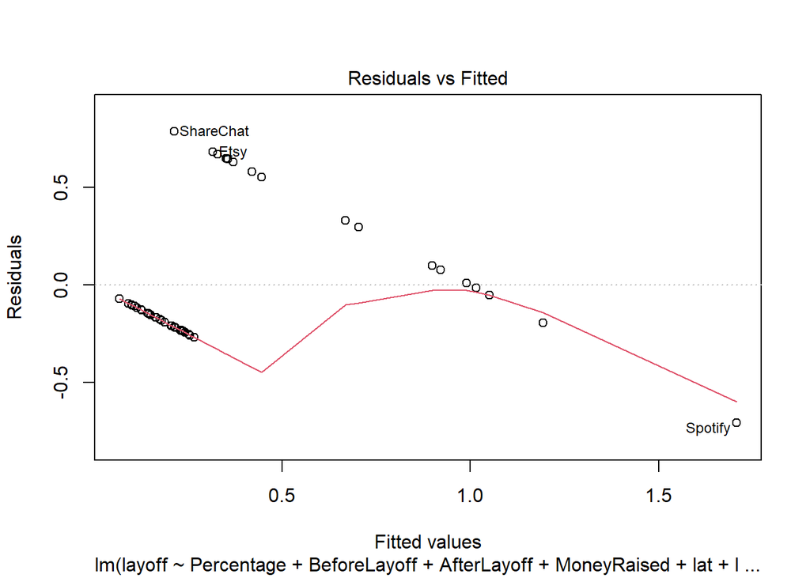

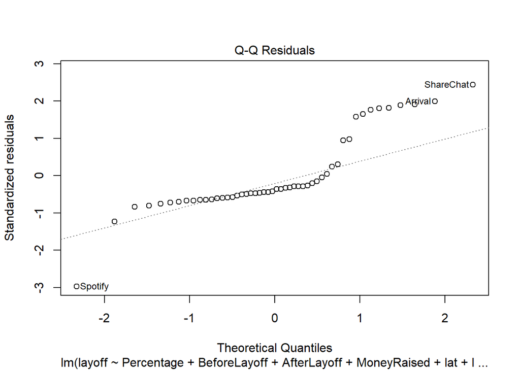

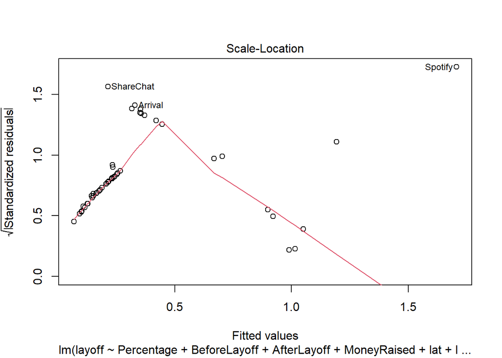

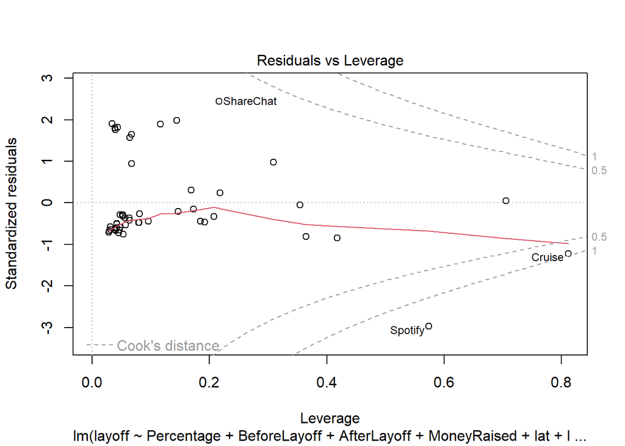

```r
plot(fit) #current one shows outlier as it is first
```

INSIGHTS : The overall regression model is significant as indicated by a low p-value (p < 0.05). BeforeLayoff and AfterLayoff variables are significant predictors of layoff, as their p-values are less than 0.05. Percentage, MoneyRaised, lat, and lng variables do not appear to be significant predictors, as their p-values are greater than 0.05.

```r
# Assessing Outliers
library(car)
outlierTest(fit)#current one shows outlier
```

```
## No Studentized residuals with Bonferroni p < 0.05
## Largest |rstudent|:
##          rstudent unadjusted p-value Bonferroni p
## Spotify -3.299983          0.0019774     0.098869
```

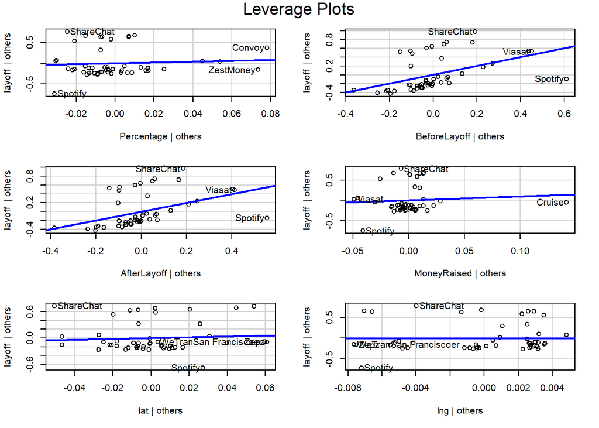

```r
leveragePlots(fit) # leverage plots
```

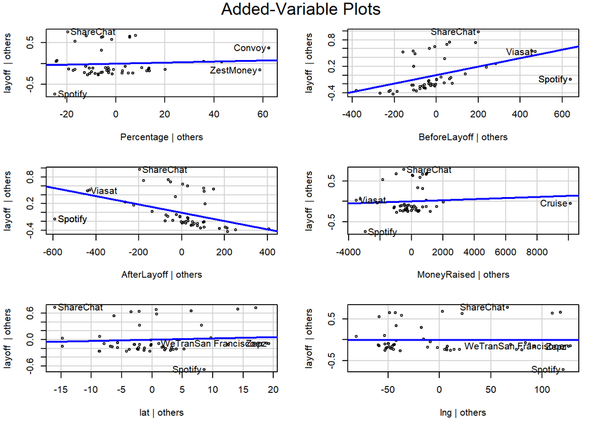

```r
# Influential Observations
# added variable plots
avPlots(fit)
```

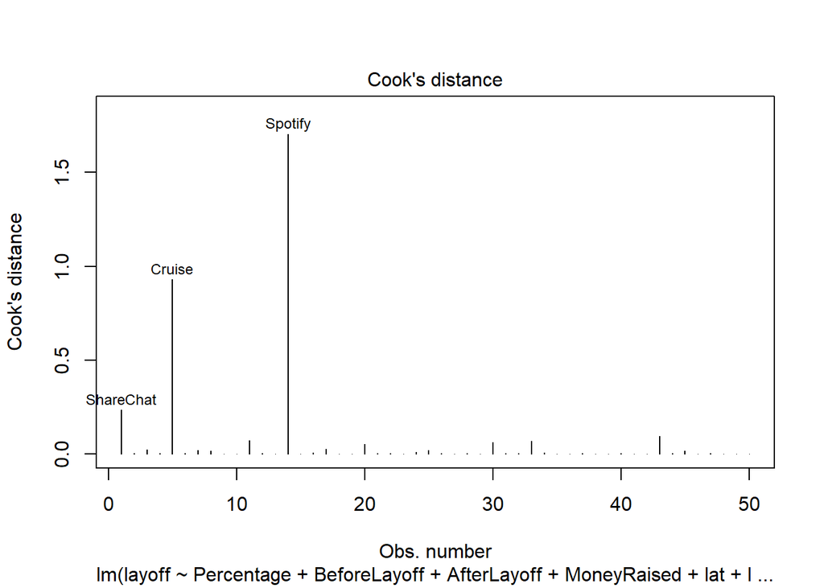

```r
# Cook's D plot
# identify D values > 4/(n-k-1)
cutoff <- 4/((nrow(mtcars)-length(fit$coefficients)-2))
plot(fit, which=4, cook.levels=cutoff)
```

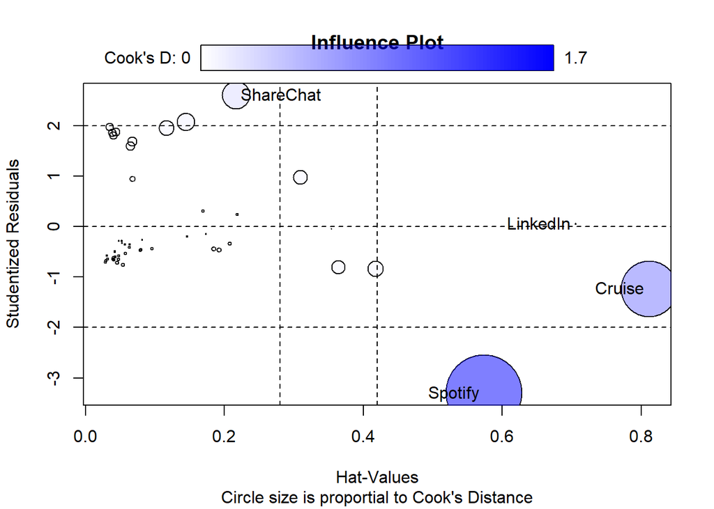

```
##               StudRes       Hat        CookD
## ShareChat  2.60019275 0.2163407 0.2351363829
## Cruise    -1.23579998 0.8116781 0.9289426756
## Spotify   -3.29998339 0.5741115 1.7049890151
## LinkedIn   0.04763859 0.7056720 0.0007957686
```

```r
# Influence Plot
influencePlot(fit, id.method="identify", main="Influence Plot", sub="Circle size is proportial to Cook's Distance" )
```

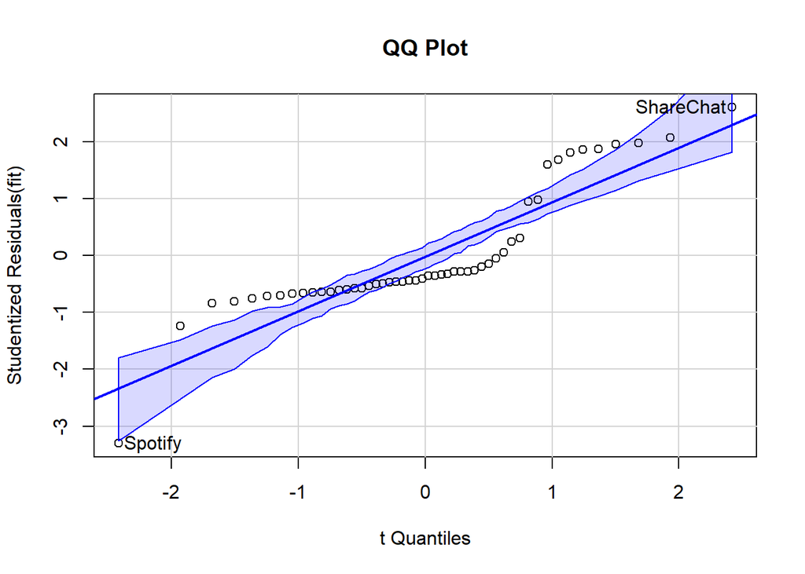

```
## ShareChat   Spotify
##         1        14
```

```r
# Normality of Residuals
# qq plot for studentized resid
qqPlot(fit, main="QQ Plot")
```

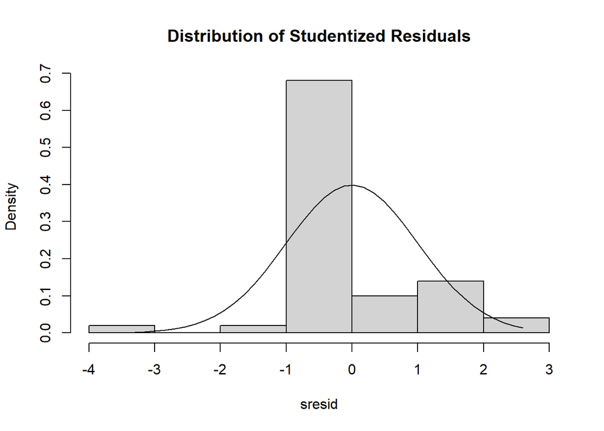

```r
# distribution of studentized residuals
library(MASS)
sresid <- studres(fit)
hist(sresid, freq=FALSE, main="Distribution of Studentized Residuals")
xfit<-seq(min(sresid),max(sresid),length=40)
yfit<-dnorm(xfit)
lines(xfit, yfit)
```

```r
#Non-constant Error Variance
# Evaluate homoscedasticity
# non-constant error variance test
ncvTest(fit)
```

```
## Non-constant Variance Score Test
## Variance formula: ~ fitted.values
## Chisquare = 1.862244, Df = 1, p = 0.17237
```

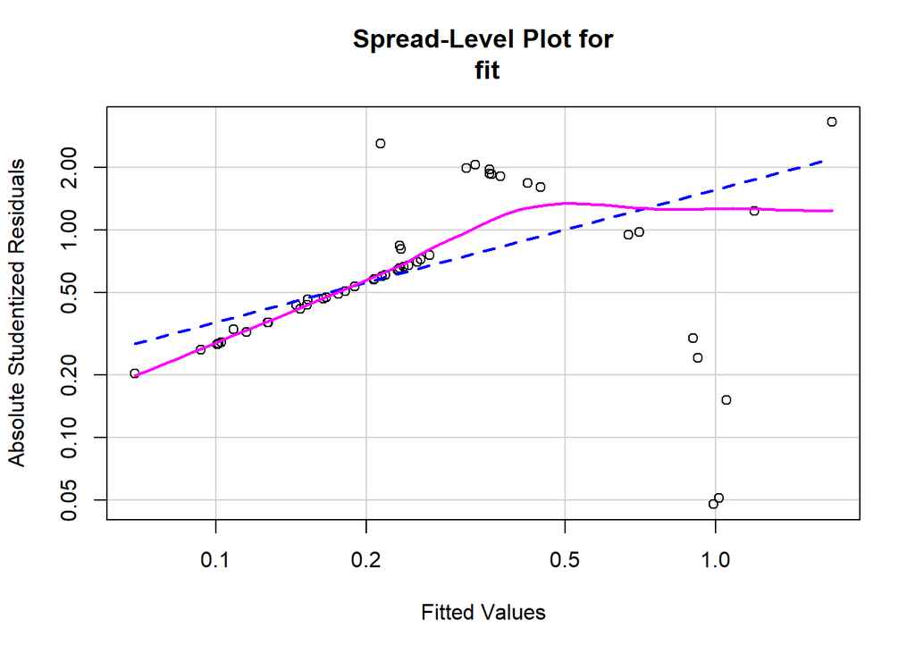

```
##
## Suggested power transformation:  0.3607173
```

```r
# plot studentized residuals vs. fitted values
spreadLevelPlot(fit)
```

```r
#Multi-collinearity
# Evaluate Collinearity
vif(fit) # variance inflation factors
```

```
##   Percentage BeforeLayoff  AfterLayoff  MoneyRaised          lat          lng
##     1.492941   449.167061   457.008308     1.551647     1.638294     1.273843
```

```r
sqrt(vif(fit)) > 2 # problem?
```

```
##   Percentage BeforeLayoff  AfterLayoff  MoneyRaised          lat          lng
##        FALSE         TRUE         TRUE        FALSE        FALSE        FALSE
```

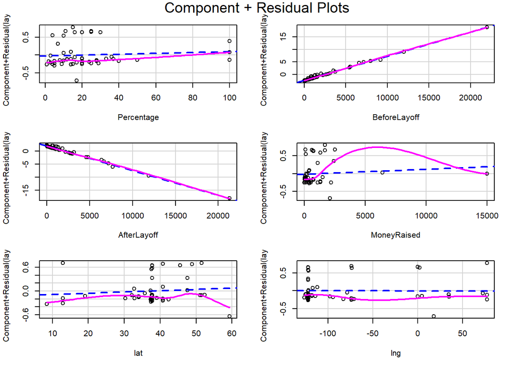

```r
#Nonlinearity
# component + residual plot
crPlots(fit)
```

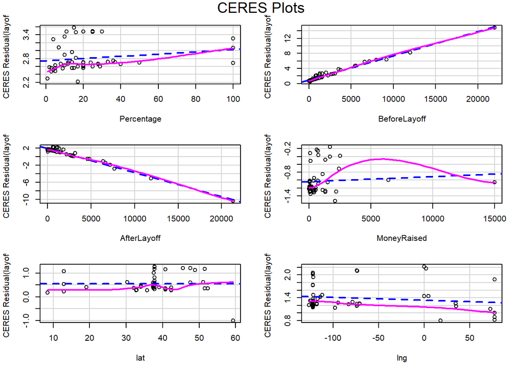

```r
# Ceres plots
ceresPlots(fit)
```

```r
#Non-independence of Errors
# Test for Autocorrelated Errors
durbinWatsonTest(fit)
```

```
##  lag Autocorrelation D-W Statistic p-value
##    1      0.03405266      1.822788   0.514
##  Alternative hypothesis: rho != 0
```

```r
# Global test of model assumptions
library(gvlma)
gvmodel <- gvlma(fit)
summary(gvmodel)
```

```
##
## Call:
## lm(formula = layoff ~ Percentage + BeforeLayoff + AfterLayoff +
##     MoneyRaised + lat + lng, data = lay_data)
##
## Residuals:
##     Min      1Q  Median      3Q     Max
## -0.7063 -0.2132 -0.1360  0.0612  0.7863
##
## Coefficients:
##                Estimate Std. Error t value Pr(>|t|)
## (Intercept)  -7.220e-02  2.537e-01  -0.285  0.77728
## Percentage    1.253e-03  2.812e-03   0.446  0.65812
## BeforeLayoff  9.551e-04  2.850e-04   3.351  0.00169 **
## AfterLayoff  -9.410e-04  2.996e-04  -3.140  0.00305 **
## MoneyRaised   1.396e-05  2.837e-05   0.492  0.62519
## lat           3.165e-03  6.627e-03   0.478  0.63532
## lng          -5.975e-05  8.544e-04  -0.070  0.94457
## ---
## Signif. codes:  0 '***' 0.001 '**' 0.01 '*' 0.05 '.' 0.1 ' ' 1
##
## Residual standard error: 0.3637 on 43 degrees of freedom
## Multiple R-squared:  0.5061, Adjusted R-squared:  0.4372
## F-statistic: 7.344 on 6 and 43 DF,  p-value: 1.91e-05
##
##
## ASSESSMENT OF THE LINEAR MODEL ASSUMPTIONS
## USING THE GLOBAL TEST ON 4 DEGREES-OF-FREEDOM:
## Level of Significance =  0.05
##
## Call:
##  gvlma(x = fit)
##
##                       Value   p-value                   Decision
## Global Stat        33.62026 8.915e-07 Assumptions NOT satisfied!
## Skewness            9.02769 2.659e-03 Assumptions NOT satisfied!
## Kurtosis            0.02139 8.837e-01    Assumptions acceptable.
## Link Function      21.70227 3.184e-06 Assumptions NOT satisfied!
## Heteroscedasticity  2.86891 9.031e-02    Assumptions acceptable.
```

```r
fit
```

```
##
## Call:
## lm(formula = layoff ~ Percentage + BeforeLayoff + AfterLayoff +
##     MoneyRaised + lat + lng, data = lay_data)
##
## Coefficients:
##  (Intercept)    Percentage  BeforeLayoff   AfterLayoff   MoneyRaised
##   -7.220e-02     1.253e-03     9.551e-04    -9.410e-04     1.396e-05
##          lat           lng
##    3.165e-03    -5.975e-05
```

```r
summary(fit)
```

```
##
## Call:
## lm(formula = layoff ~ Percentage + BeforeLayoff + AfterLayoff +
##     MoneyRaised + lat + lng, data = lay_data)
##
## Residuals:
##     Min      1Q  Median      3Q     Max
## -0.7063 -0.2132 -0.1360  0.0612  0.7863
##
## Coefficients:
##                Estimate Std. Error t value Pr(>|t|)
## (Intercept)  -7.220e-02  2.537e-01  -0.285  0.77728
## Percentage    1.253e-03  2.812e-03   0.446  0.65812
## BeforeLayoff  9.551e-04  2.850e-04   3.351  0.00169 **
## AfterLayoff  -9.410e-04  2.996e-04  -3.140  0.00305 **
## MoneyRaised   1.396e-05  2.837e-05   0.492  0.62519
## lat           3.165e-03  6.627e-03   0.478  0.63532
## lng          -5.975e-05  8.544e-04  -0.070  0.94457
## ---
## Signif. codes:  0 '***' 0.001 '**' 0.01 '*' 0.05 '.' 0.1 ' ' 1
##
## Residual standard error: 0.3637 on 43 degrees of freedom
## Multiple R-squared:  0.5061, Adjusted R-squared:  0.4372
## F-statistic: 7.344 on 6 and 43 DF,  p-value: 1.91e-05
```

```r
fit1 <- fit
fit2 <- lm(layoff~Percentage + BeforeLayoff + AfterLayoff + MoneyRaised + lat + lng, data = lay_data)
# compare models
```

```r
# ACCURACY

anova(fit1, fit2)
```

```
## Analysis of Variance Table
##
## Model 1: layoff ~ Percentage + BeforeLayoff + AfterLayoff + MoneyRaised +
##     lat + lng
## Model 2: layoff ~ Percentage + BeforeLayoff + AfterLayoff + MoneyRaised +
##     lat + lng
##   Res.Df    RSS Df Sum of Sq F Pr(>F)
## 1     43 5.6894
## 2     43 5.6894  0         0
```

```r
step <- stepAIC(fit, direction="both")
```

```
## Start:  AIC=-94.67
## layoff ~ Percentage + BeforeLayoff + AfterLayoff + MoneyRaised +
##     lat + lng
##
##                Df Sum of Sq    RSS     AIC
## - lng           1   0.00065 5.6901 -96.665
## - Percentage    1   0.02627 5.7157 -96.440
## - lat           1   0.03019 5.7196 -96.406
## - MoneyRaised   1   0.03203 5.7215 -96.390
## <none>                      5.6894 -94.671
## - AfterLayoff   1   1.30484 6.9943 -86.347
## - BeforeLayoff  1   1.48586 7.1753 -85.069
##
## Step:  AIC=-96.67
## layoff ~ Percentage + BeforeLayoff + AfterLayoff + MoneyRaised +
##     lat
##
##                Df Sum of Sq    RSS     AIC
## - Percentage    1   0.02695 5.7170 -98.429
## - MoneyRaised   1   0.03468 5.7247 -98.361
## - lat           1   0.04310 5.7332 -98.288
## <none>                      5.6901 -96.665
## + lng           1   0.00065 5.6894 -94.671
## - AfterLayoff   1   1.33443 7.0245 -88.131
## - BeforeLayoff  1   1.51957 7.2096 -86.830
##
## Step:  AIC=-98.43
## layoff ~ BeforeLayoff + AfterLayoff + MoneyRaised + lat
##
##                Df Sum of Sq    RSS      AIC
## - MoneyRaised   1   0.02128 5.7383 -100.243
## - lat           1   0.02875 5.7458 -100.178
## <none>                      5.7170  -98.429
## + Percentage    1   0.02695 5.6901  -96.665
## + lng           1   0.00132 5.7157  -96.440
## - AfterLayoff   1   2.02547 7.7425  -85.265
## - BeforeLayoff  1   2.23490 7.9519  -83.931
##
## Step:  AIC=-100.24
## layoff ~ BeforeLayoff + AfterLayoff + lat
##
##                Df Sum of Sq    RSS      AIC
## - lat           1    0.0205 5.7588 -102.065
## <none>                      5.7383 -100.243
## + MoneyRaised   1    0.0213 5.7170  -98.429
## + Percentage    1    0.0135 5.7247  -98.361
## + lng           1    0.0035 5.7348  -98.274
## - AfterLayoff   1    3.0664 8.8047  -80.837
## - BeforeLayoff  1    3.3938 9.1321  -79.012
##
## Step:  AIC=-102.07
## layoff ~ BeforeLayoff + AfterLayoff
##
##                Df Sum of Sq    RSS      AIC
## <none>                      5.7588 -102.065
## + lat           1    0.0205 5.7383 -100.243
## + lng           1    0.0133 5.7455 -100.180
## + MoneyRaised   1    0.0130 5.7458 -100.178
## + Percentage    1    0.0070 5.7518 -100.126
## - AfterLayoff   1    3.7511 9.5099  -78.984
## - BeforeLayoff  1    4.1188 9.8775  -77.088
```

```r
step$anova # display results
```

```
## Stepwise Model Path
## Analysis of Deviance Table
##
## Initial Model:
## layoff ~ Percentage + BeforeLayoff + AfterLayoff + MoneyRaised +
##     lat + lng
##
## Final Model:
## layoff ~ BeforeLayoff + AfterLayoff
##
##
##            Step Df     Deviance Resid. Df Resid. Dev        AIC
## 1                                      43   5.689421  -94.67073
## 2         - lng  1 0.0006470119        44   5.690068  -96.66504
## 3  - Percentage  1 0.0269453347        45   5.717013  -98.42883
## 4 - MoneyRaised  1 0.0212756041        46   5.738289 -100.24310
## 5         - lat  1 0.0204673860        47   5.758756 -102.06508
```

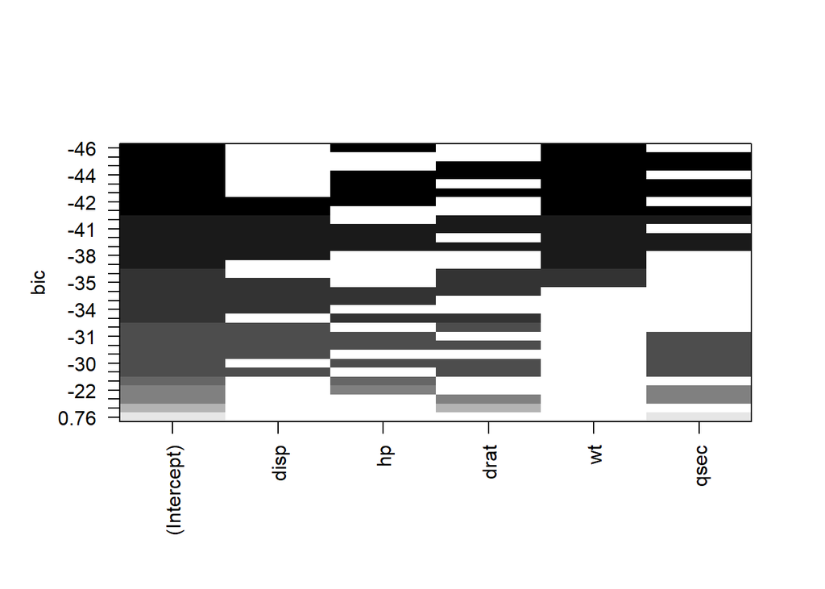

```r
library(leaps)
leaps<-regsubsets(mpg~disp+hp+drat+wt+qsec,data=mtcars,nbest=10)
# view results
plot(leaps)
```

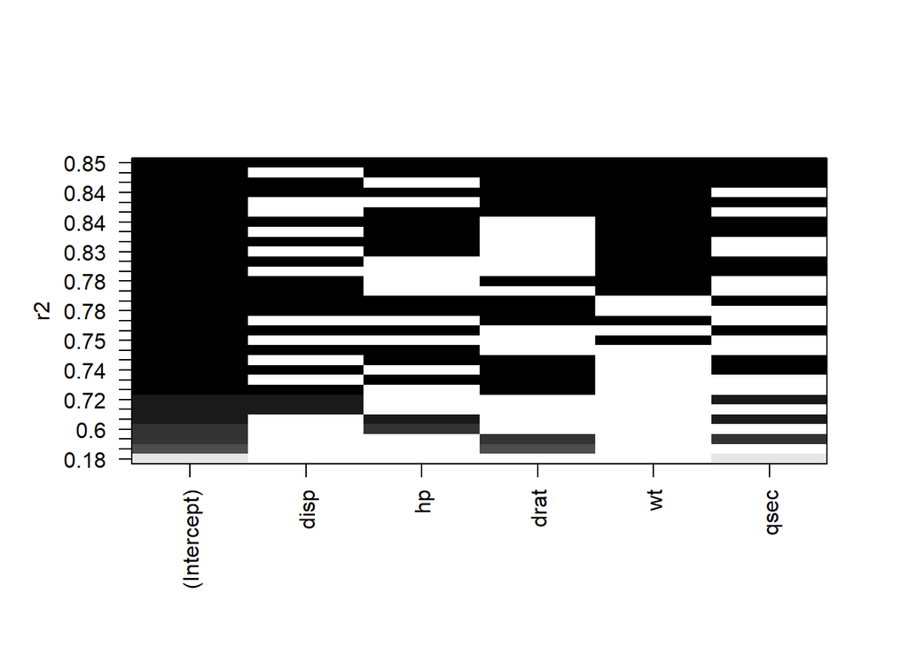

```r
plot(leaps,scale="r2")
```

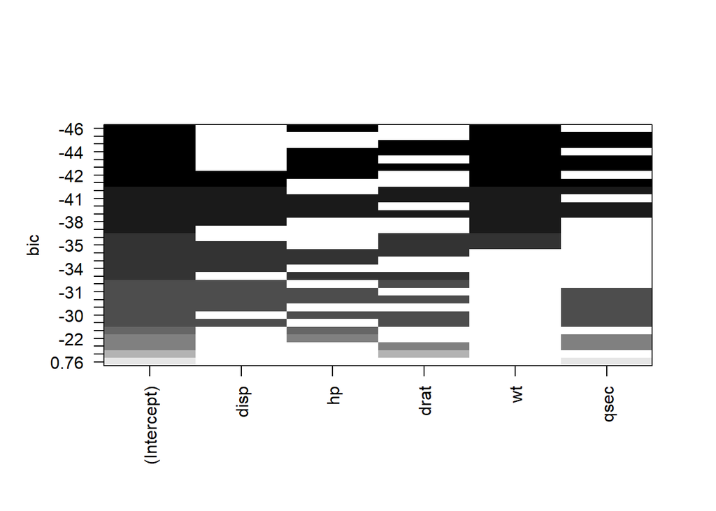

```r
plot(leaps,scale="bic")
```

```r
summary(leaps)
```

```
## Subset selection object
## Call: regsubsets.formula(mpg ~ disp + hp + drat + wt + qsec, data = mtcars,
##     nbest = 10)
## 5 Variables  (and intercept)
##      Forced in Forced out
## disp     FALSE      FALSE
## hp       FALSE      FALSE
## drat     FALSE      FALSE
## wt       FALSE      FALSE
## qsec     FALSE      FALSE
## 10 subsets of each size up to 5
## Selection Algorithm: exhaustive
##           disp hp  drat wt  qsec
## 1  ( 1 )  " "  " " " "  "*" " "
## 1  ( 2 )  "*"  " " " "  " " " "
```

[output cut: 29 more lines]

```r
library(relaimpo)
calc.relimp(fit,type=c("lmg","last","first","pratt"),
            rela=TRUE)
```

```
## Response variable: layoff
## Total response variance: 0.235102
## Analysis based on 50 observations
##
## 6 Regressors:
## Percentage BeforeLayoff AfterLayoff MoneyRaised lat lng
## Proportion of variance explained by model: 50.61%
## Metrics are normalized to sum to 100% (rela=TRUE).
##
## Relative importance metrics:
##
##                     lmg         last      first        pratt
## Percentage   0.04656156 0.0091227188 0.01570950  0.010264714
## BeforeLayoff 0.38643338 0.5159522812 0.34577795  6.281877544
## AfterLayoff  0.33829200 0.4530947665 0.28253747 -5.367557330
## MoneyRaised  0.14929601 0.0111236311 0.24935182  0.046037121
## lat          0.07334944 0.0104819329 0.09248598  0.027966406
## lng          0.00606762 0.0002246694 0.01413728  0.001411545
##
## Average coefficients for different model sizes:
##
##                         1X           2Xs           3Xs           4Xs
## Percentage    1.912130e-03  3.408211e-03  0.0040522172  3.859741e-03
## BeforeLayoff  5.241622e-05  2.622794e-04  0.0004627982  6.502314e-04
## AfterLayoff   4.938547e-05 -1.758703e-04 -0.0003929315 -5.981195e-04
## MoneyRaised   7.537404e-05  7.208342e-05  0.0000636468  5.074004e-05
## lat           1.043649e-02  1.116853e-02  0.0109795319  9.679265e-03
## lng          -5.966520e-04 -4.162820e-04 -0.0001857820  7.842943e-06
##                        5Xs           6Xs
## Percentage    2.893972e-03  1.253125e-03
## BeforeLayoff  8.178008e-04  9.551032e-04
## AfterLayoff  -7.844445e-04 -9.410057e-04
## MoneyRaised   3.402389e-05  1.395757e-05
## lat           7.100878e-03  3.165247e-03
## lng           7.389907e-05 -5.975064e-05
```

INSIGHTS : The final selected model (layoff ~ BeforeLayoff + AfterLayoff) has the lowest AIC value (-102.065) among all evaluated models. This model includes only the BeforeLayoff and AfterLayoff predictors, indicating that these variables alone provide the best balance of model complexity and explanatory power for predicting layoff.

```r
# Bootstrap Measures of Relative Importance (1000 samples)
boot <- boot.relimp(fit, b = 1000, type = c("lmg",
                                            "last", "first", "pratt"), rank = TRUE,
                    diff = TRUE, rela = TRUE)
booteval.relimp(boot) # print result
```

```
## Response variable: layoff
## Total response variance: 0.235102
## Analysis based on 50 observations
##
## 6 Regressors:
## Percentage BeforeLayoff AfterLayoff MoneyRaised lat lng
## Proportion of variance explained by model: 50.61%
## Metrics are normalized to sum to 100% (rela=TRUE).
##
## Relative importance metrics:
##
##                     lmg         last      first        pratt
## Percentage   0.04656156 0.0091227188 0.01570950  0.010264714
## BeforeLayoff 0.38643338 0.5159522812 0.34577795  6.281877544
## AfterLayoff  0.33829200 0.4530947665 0.28253747 -5.367557330
## MoneyRaised  0.14929601 0.0111236311 0.24935182  0.046037121
## lat          0.07334944 0.0104819329 0.09248598  0.027966406
## lng          0.00606762 0.0002246694 0.01413728  0.001411545
##
## Average coefficients for different model sizes:
##
##                         1X           2Xs           3Xs           4Xs
## Percentage    1.912130e-03  3.408211e-03  0.0040522172  3.859741e-03
## BeforeLayoff  5.241622e-05  2.622794e-04  0.0004627982  6.502314e-04
## AfterLayoff   4.938547e-05 -1.758703e-04 -0.0003929315 -5.981195e-04
## MoneyRaised   7.537404e-05  7.208342e-05  0.0000636468  5.074004e-05
## lat           1.043649e-02  1.116853e-02  0.0109795319  9.679265e-03
## lng          -5.966520e-04 -4.162820e-04 -0.0001857820  7.842943e-06
##                        5Xs           6Xs
## Percentage    2.893972e-03  1.253125e-03
## BeforeLayoff  8.178008e-04  9.551032e-04
## AfterLayoff  -7.844445e-04 -9.410057e-04
## MoneyRaised   3.402389e-05  1.395757e-05
## lat           7.100878e-03  3.165247e-03
## lng           7.389907e-05 -5.975064e-05
##
##
##  Confidence interval information ( 1000 bootstrap replicates, bty= perc ):
## Relative Contributions with confidence intervals:
##
```

[output cut: 90 more lines]

```
## Percentage-lat.pratt            -0.0177         -0.2557   0.1672
## Percentage-lng.pratt             0.0089         -0.1135   0.1604
## BeforeLayoff-AfterLayoff.pratt  11.6494    *     0.3050  26.7220
## BeforeLayoff-MoneyRaised.pratt   6.2358    *     0.2109  14.0496
## BeforeLayoff-lat.pratt           6.2539    *     0.1337  13.8589
## BeforeLayoff-lng.pratt           6.2805    *     0.3717  13.9370
## AfterLayoff-MoneyRaised.pratt   -5.4136    *   -12.6164  -0.1469
## AfterLayoff-lat.pratt           -5.3955        -12.8632   0.0927
## AfterLayoff-lng.pratt           -5.3690        -12.8042   0.1351
## MoneyRaised-lat.pratt            0.0181         -0.2881   0.3299
## MoneyRaised-lng.pratt            0.0446         -0.2186   0.3418
## lat-lng.pratt                    0.0266         -0.1330   0.2960
##
## * indicates that CI for difference does not include 0.
## CAUTION: Bootstrap confidence intervals can be somewhat liberal.
```

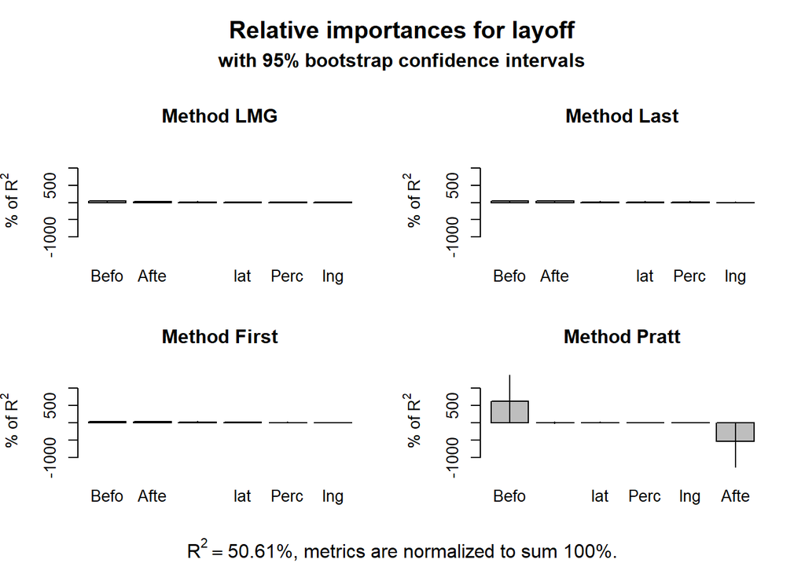

```r
plot(booteval.relimp(boot,sort=TRUE)) # plot result
```

INSIGHTS : Total response variance: 0.235102 Analysis based on 50 observations. Proportion of variance explained by the model: 50.61%.

```r
# ACCURACY

summary(fit)
```

```
##
## Call:
## lm(formula = layoff ~ Percentage + BeforeLayoff + AfterLayoff +
##     MoneyRaised + lat + lng, data = lay_data)
##
## Residuals:
##     Min      1Q  Median      3Q     Max
## -0.7063 -0.2132 -0.1360  0.0612  0.7863
##
## Coefficients:
##                Estimate Std. Error t value Pr(>|t|)
## (Intercept)  -7.220e-02  2.537e-01  -0.285  0.77728
## Percentage    1.253e-03  2.812e-03   0.446  0.65812
## BeforeLayoff  9.551e-04  2.850e-04   3.351  0.00169 **
## AfterLayoff  -9.410e-04  2.996e-04  -3.140  0.00305 **
## MoneyRaised   1.396e-05  2.837e-05   0.492  0.62519
## lat           3.165e-03  6.627e-03   0.478  0.63532
## lng          -5.975e-05  8.544e-04  -0.070  0.94457
## ---
## Signif. codes:  0 '***' 0.001 '**' 0.01 '*' 0.05 '.' 0.1 ' ' 1
##
## Residual standard error: 0.3637 on 43 degrees of freedom
## Multiple R-squared:  0.5061, Adjusted R-squared:  0.4372
## F-statistic: 7.344 on 6 and 43 DF,  p-value: 1.91e-05
```

```r
# PREDICTION

predict.lm(fit, data.frame(Percentage =0.5 ,BeforeLayoff=10,AfterLayoff = 8,MoneyRaised = 2000,lat = 40,lng = -75,hp=130) )
```

```
##          1
## 0.08945364
```

INSIGHTS : The function predicts the value of the response variable for a specific set of predictor variable values. In this case, the predicted value of the response variable (layoff) is approximately 0.0895.